# Chapter 3 : Exponential Smoothing

Amit Agni

05/10/2018

These are the course notes from the Datacamp course Forecasting using R by Rob Hyndman.

### Simple Exponential smoothing

Naive() uses the last observation and meanf() uses the mean of all the observations. ESP is in between.

Simple exponential smoothing is suitable for forecasting data with no clear trend or seasonal pattern.

Forecasts are calculated using weighted averages, where the weights decrease exponentially as observations come from further in the past — the smallest weights are associated with the oldest observations.

Forecast Equation :

$\hat{y}_{T+1 | T} = \alpha y_{T} + \alpha(1-\alpha)y_{T-1} + \alpha(1-\alpha) ^{2}y_{T-2} + ....$

where $0 \leq \alpha \leq 1$ is the smoothing parameter.

The one-step-ahead forecast for time $T+1$ is a weighted average of all the observations in the series $y_{1},..., y_{T}$. The rate at which the weights descrease is controlled by $\alpha$

> For any between 0 and 1, the weights attached to the observations decrease exponentially as we go back in time, hence the name “exponential smoothing”. If $\alpha$ is small (i.e., close to 0), more weight is given to observations from the more distant past. If $\alpha$ is large (i.e., close to 1), more weight is given to the more recent observations.

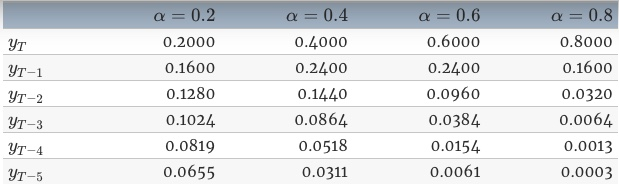

> The **ses()** function produces forecasts obtained using simple exponential smoothing (SES). The parameters are estimated using least squares estimation. All you need to specify is the time series and the forecast horizon; the default forecast time is h = 10 years.

> **fitted()** is a generic function which extracts fitted values from objects returned by modeling functions. fitted.values is an alias for it.

> **autolayer()** uses ggplot2 to draw a particular layer for an object of a particular class in a single command.

```r
# Use ses() to forecast the next 10 years of winning times
fc <- ses(marathon, h = 10)

# Use summary() to see the model parameters
summary(fc)
```

```
##
## Forecast method: Simple exponential smoothing
##
## Model Information:
## Simple exponential smoothing
##
## Call:
##  ses(y = marathon, h = 10)
##
##   Smoothing parameters:
##     alpha = 0.3457
##
##   Initial states:
##     l = 167.1741
##
##   sigma:  5.519
##
##      AIC     AICc      BIC
## 988.4474 988.6543 996.8099
##
## Error measures:
##                      ME     RMSE      MAE        MPE     MAPE      MASE
## Training set -0.8874349 5.472771 3.826294 -0.7097395 2.637644 0.8925685
##                     ACF1
## Training set -0.01211236
##
## Forecasts:
##      Point Forecast    Lo 80    Hi 80    Lo 95    Hi 95
## 2017       130.3563 123.2835 137.4292 119.5394 141.1733
## 2018       130.3563 122.8727 137.8399 118.9111 141.8015
## 2019       130.3563 122.4833 138.2293 118.3156 142.3970
## 2020       130.3563 122.1123 138.6003 117.7482 142.9644
## 2021       130.3563 121.7573 138.9553 117.2053 143.5074
## 2022       130.3563 121.4164 139.2963 116.6839 144.0288
## 2023       130.3563 121.0880 139.6247 116.1816 144.5310
## 2024       130.3563 120.7708 139.9418 115.6966 145.0161
## 2025       130.3563 120.4639 140.2488 115.2271 145.4856
## 2026       130.3563 120.1661 140.5466 114.7717 145.9409
```

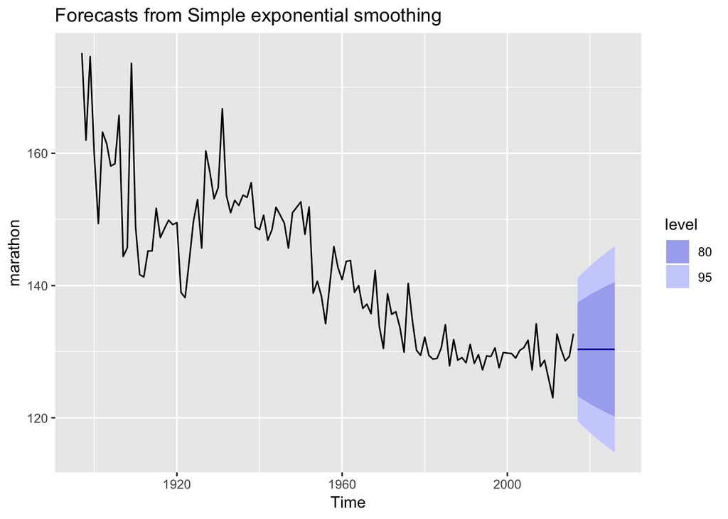

```r
# Use autoplot() to plot the forecasts
autoplot(fc)
```

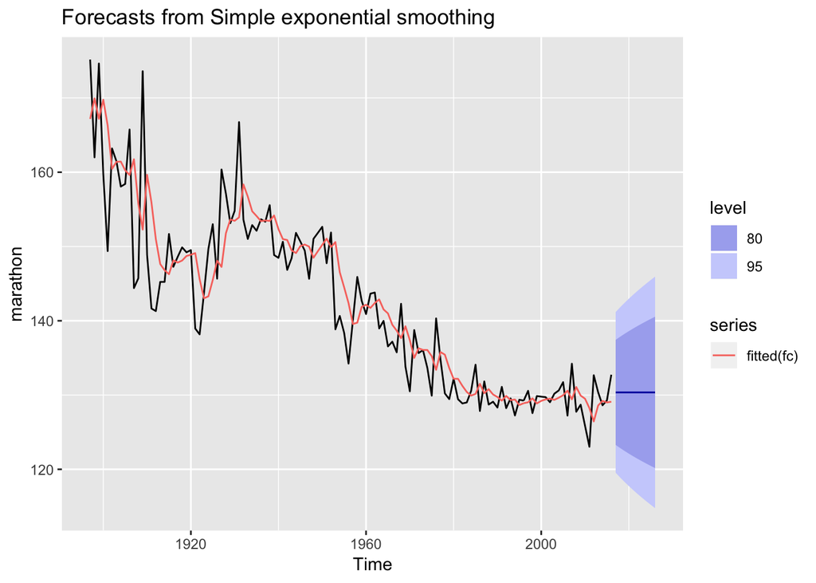

```r
# Add the one-step forecasts for the training data to the plot
autoplot(fc) + autolayer(fitted(fc))
```

Example to calculate the forecast accuracy

```r
#Using subset.ts(), create a training set for marathon comprising all but the last 20 years of the data which you will reserve for testing.

# Create a training set using subset()
train <- subset(marathon, end = length(marathon) - 20)

# Compute SES and naive forecasts, save to fcses and fcnaive
fcses <- ses(train, h = 20)
fcnaive <- naive(train, h = 20)

# Calculate forecast accuracy measures
accuracy(fcses, marathon)
```

```
##                      ME     RMSE      MAE        MPE     MAPE      MASE
## Training set -1.0851741 5.863790 4.155948 -0.8603998 2.827993 0.8990906
## Test set      0.4574579 2.493971 1.894237  0.3171919 1.463862 0.4097960
##                     ACF1 Theil's U
## Training set -0.01595953        NA
## Test set     -0.12556096 0.6870735
```

```r
accuracy(fcnaive, marathon)
```

```
##                      ME     RMSE      MAE        MPE     MAPE      MASE
## Training set -0.4638047 6.904742 4.622391 -0.4086317 3.123559 1.0000000
## Test set      0.2266667 2.462113 1.846667  0.1388780 1.429608 0.3995047
##                    ACF1 Theil's U
## Training set -0.3589323        NA
## Test set     -0.1255610 0.6799062
```

```r
# Save the best forecasts as
#More complex models aren't always better!
fcbest <- fcnaive
```

### Exponential Smoothing with Trend

> Holt (1957) extended simple exponential smoothing to allow the forecasting of data with a trend. This method involves a forecast equation and two smoothing equations (one for the level and one for the trend):

> Forecast equation $\hat{y}_{t+h|t} = \ell_{t} + hb_{t}$  
> Level equation $\ell_{t} = \alpha y_{t} + (1 -\alpha)(\ell_{t-1} + b_{t-1})$  
> Trend equation $b_{t} = \beta^*(\ell_{t} - \ell_{t-1}) + (1 -\beta^*)b_{t-1}$  
> where  
> $\ell_t$ denotes an estimate of the level of the series at time $t$  
> $b_t$ denotes an estimate of the trend (slope) of the series at time $t$  
> $\alpha$ is the smoothing parameter for the level $0\le\alpha\le1$  
> $\beta^*$ is the smoothing parameter for the trend $0\le\beta^*\le1$  
> (We denote this as $\beta^*$ instead of $\beta$ for reasons that will be explained in Section 7.5

> Gardner & McKenzie (1985) introduced a parameter that “dampens” the trend to a flat line some time in the future. Methods that include a damped trend have proven to be very successful, and are arguably the most popular individual methods when forecasts are required automatically for many series.

```r
tail(austa,10)
```

```
## Time Series:
## Start = 2006
## End = 2015
## Frequency = 1
##  [1] 5.063435 5.145489 5.099436 5.088166 5.353702 5.343327 5.589162
##  [8] 5.904884 6.357183 6.858953
```

```r
# Produce 10 year forecasts of austa using holt()
fcholt <- holt(austa, h = 10)

# Look at fitted model using summary()
summary(fcholt)
```

```
##
## Forecast method: Holt's method
##
## Model Information:
## Holt's method
##
## Call:
##  holt(y = austa, h = 10)
##
##   Smoothing parameters:
##     alpha = 0.9999
##     beta  = 0.0085
##
##   Initial states:
##     l = 0.656
##     b = 0.1706
##
##   sigma:  0.1952
##
##      AIC     AICc      BIC
## 17.14959 19.14959 25.06719
##
## Error measures:
##                      ME      RMSE       MAE       MPE     MAPE      MASE
## Training set 0.00372838 0.1840662 0.1611085 -1.222083 5.990319 0.7907078
##                   ACF1
## Training set 0.2457733
##
## Forecasts:
##      Point Forecast    Lo 80    Hi 80    Lo 95    Hi 95
## 2016       7.030683 6.780483 7.280882 6.648036 7.413330
## 2017       7.202446 6.847114 7.557778 6.659013 7.745879
## 2018       7.374209 6.937169 7.811249 6.705814 8.042604
## 2019       7.545972 7.039179 8.052765 6.770899 8.321045
## 2020       7.717736 7.148723 8.286748 6.847506 8.587965
## 2021       7.889499 7.263543 8.515455 6.932181 8.846816
## 2022       8.061262 7.382302 8.740222 7.022882 9.099642
## 2023       8.233025 7.504136 8.961915 7.118285 9.347766
## 2024       8.404788 7.628444 9.181133 7.217472 9.592105
## 2025       8.576552 7.754792 9.398311 7.319779 9.833324
```

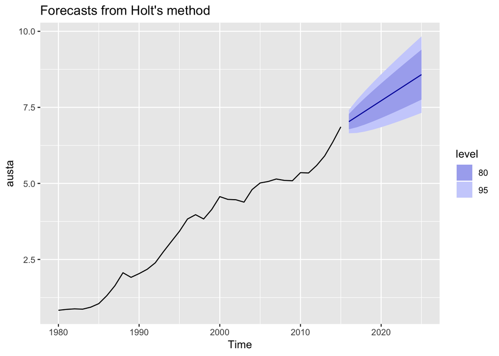

```r
# Plot the forecasts
autoplot(fcholt)
```

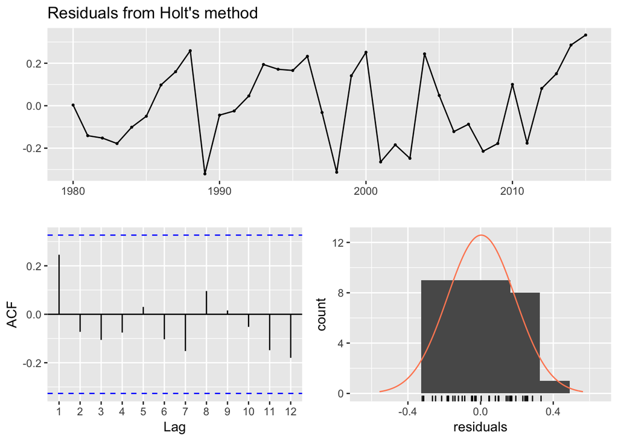

```
##
##  Ljung-Box test
##
## data:  Residuals from Holt's method
## Q* = 4.8886, df = 3.2, p-value = 0.2022
##
## Model df: 4.   Total lags used: 7.2
```

```r
# Check that the residuals look like white noise
checkresiduals(fcholt)
```

Forecasting using damped method

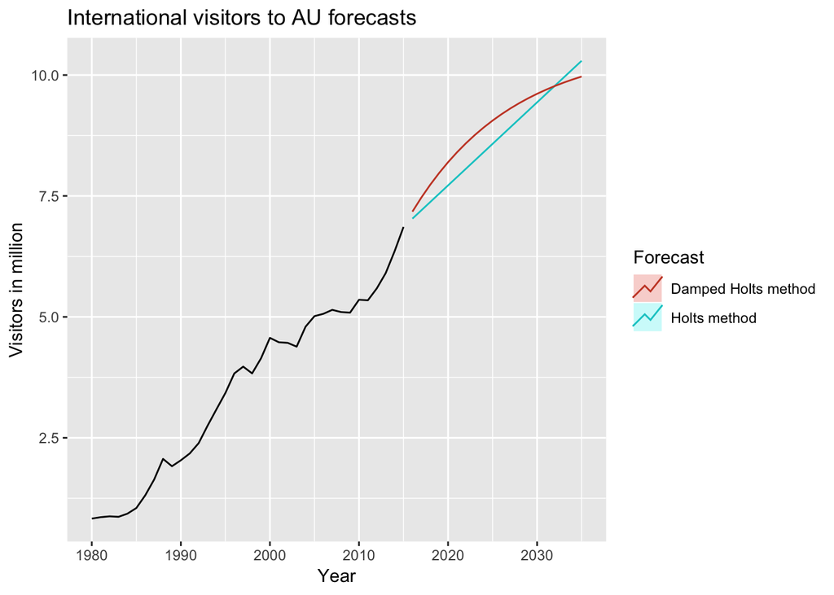

```r
#PI - Prediction intervals
autoplot(austa) +
    autolayer(holt(austa,h=20), series ="Holts method", PI=FALSE) +
    autolayer(holt(austa,h=20,damped = TRUE), series ="Damped Holts method",PI=FALSE) +
    ggtitle("International visitors to AU forecasts") +
    xlab("Year") +
    ylab("Visitors in million") +
    guides(colour=guide_legend(title="Forecast"))
```

### Exponential Smoothing with Trend and Seasonality

> Holt (1957) and Winters (1960) extended Holt’s method to capture seasonality. The Holt-Winters seasonal method comprises the forecast equation and three smoothing equations — one for the level $\ell_t$, one for the trend $b_t$, and one for the seasonal component $s_t$, with corresponding smoothing parameters $\alpha$, $\beta^∗$ and $\gamma$.We use $m$ to denote the frequency of the seasonality, i.e., the number of seasons in a year. For example, for quarterly data $m=4$, and for monthly data $m=12$

> There are two variations to this method that differ in the nature of the seasonal component.
> - The additive method is preferred when the seasonal variations are roughly constant through the series, while the multiplicative method is preferred when the seasonal variations are changing proportional to the level of the series.
> - With the additive method, the seasonal component is expressed in absolute terms in the scale of the observed series, and in the level equation the series is seasonally adjusted by subtracting the seasonal component. Within each year, the seasonal component will add up to approximately zero.
> - With the multiplicative method, the seasonal component is expressed in relative terms (percentages), and the series is seasonally adjusted by dividing through by the seasonal component. Within each year, the seasonal component will sum up to approximately $m$

> The different methods are summarised in this table

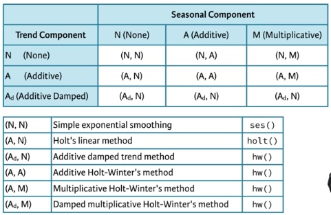

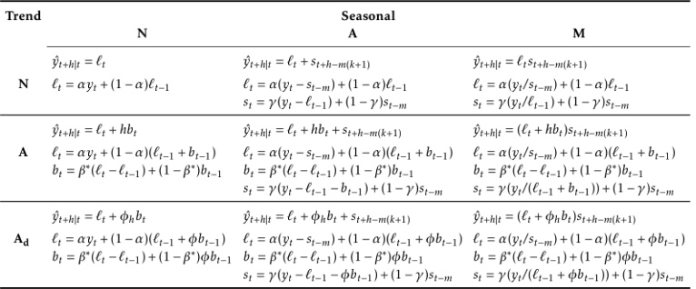

Example

```r
tail(a10,20)
```

```
##           Jan      Feb      Mar      Apr      May      Jun      Jul
## 2006
## 2007 28.03838 16.76387 19.79275 16.42731 21.00074 20.68100 21.83489
## 2008 29.66536 21.65429 18.26495 23.10768 22.91251 19.43174
##           Aug      Sep      Oct      Nov      Dec
## 2006                            23.57552 23.33421
## 2007 23.93020 22.93036 23.26334 25.25003 25.80609
## 2008
```

```r
frequency(a10)
```

```
## [1] 12
```

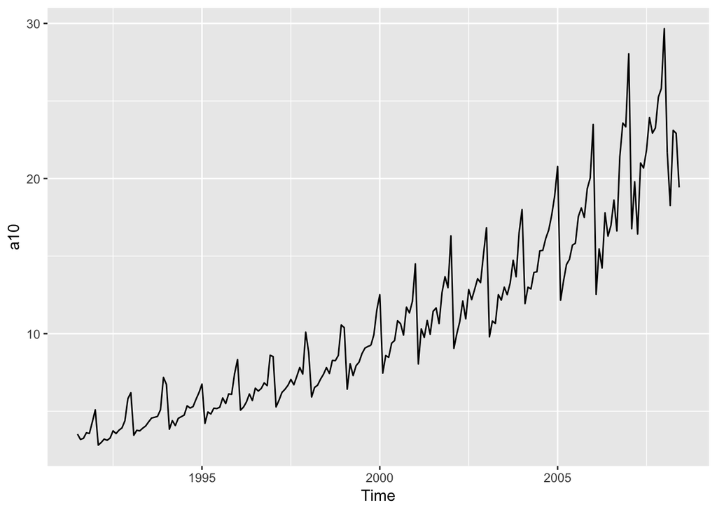

```r
# Plot the data
autoplot(a10)
```

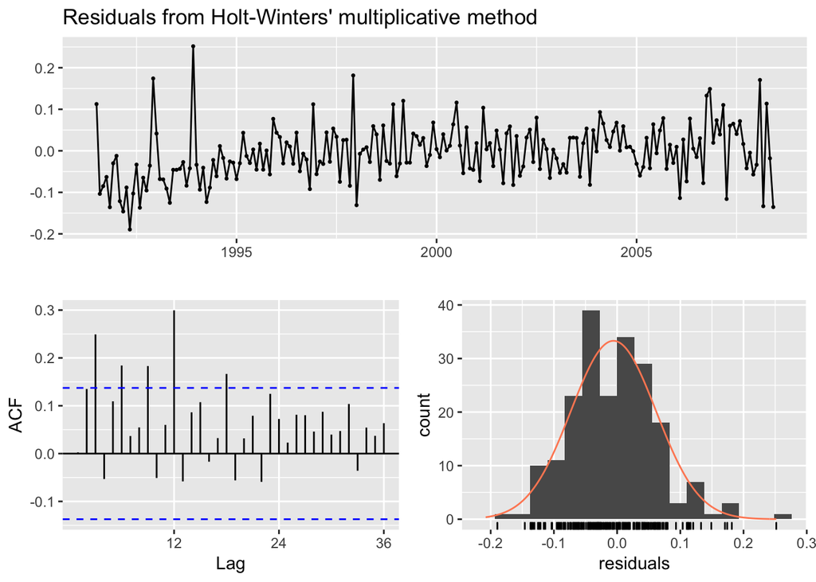

```
##
##  Ljung-Box test
##
## data:  Residuals from Holt-Winters' multiplicative method
## Q* = 75.764, df = 8, p-value = 3.467e-13
##
## Model df: 16.   Total lags used: 24
```

```r
# Produce 3 year forecasts
fc <- hw(a10, seasonal = "multiplicative", h = 12*3)

# Check if residuals look like white noise
# The forecasts might still provide useful information even with residuals that fail the white noise test.
checkresiduals(fc)
```

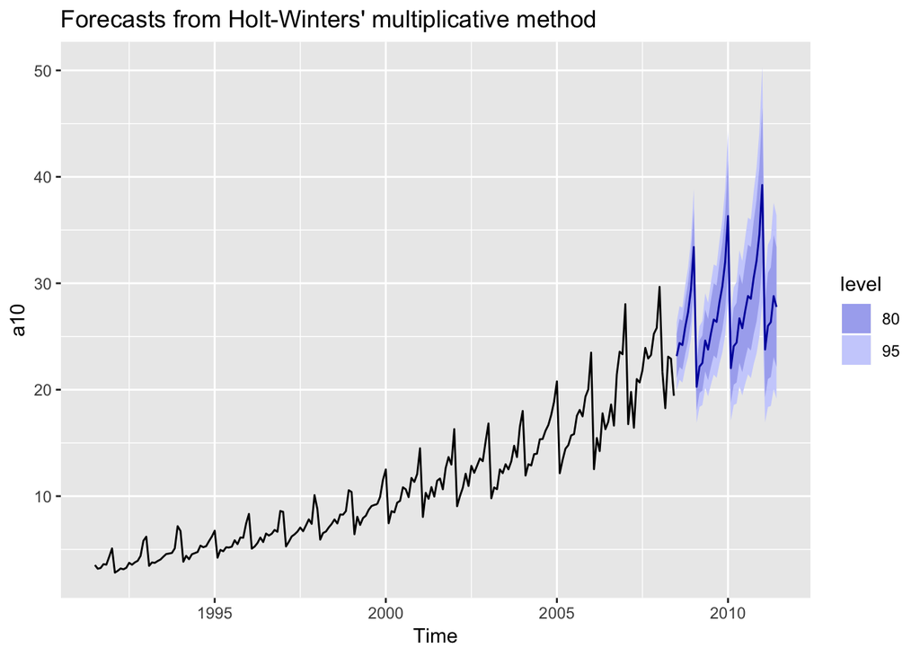

```r
whitenoise <- FALSE

# Plot forecasts
autoplot(fc)
```

##### Holt-Winters method with daily data

The Holt-Winters method can also be used for daily type of data, where the seasonal pattern is of length 7, and the appropriate unit of time for h is in days.

```r
head(hyndsight,10)
```

```
## Time Series:
## Start = c(1, 4)
## End = c(2, 6)
## Frequency = 7
##  [1] 1157 1118 1310  874  890 1437 1263 1187 1506 1448
```

```r
# Create training data with subset()
#set up a training set where the last 4 weeks of the available data in hyndsight have been omitted.
train <- subset(hyndsight, end = length(hyndsight) - 28)

# Holt-Winters additive forecasts
#Produce forecasts for these last 4 weeks using hw() and additive seasonality applied to the training data.
fchw <- hw(train, seasonal = "additive", h = 28)

# Seasonal naive forecasts as fcsn
fcsn <- snaive(train,h=28)

# Find better forecasts with accuracy()
accuracy(fchw, hyndsight)
```

```
##                     ME     RMSE      MAE       MPE    MAPE      MASE
## Training set -3.976241 228.2440 165.0244 -2.407211 13.9955 0.7492131
## Test set     -3.999460 201.7656 152.9584 -3.218292 10.5558 0.6944332
##                   ACF1 Theil's U
## Training set 0.1900853        NA
## Test set     0.3013328 0.4868701
```

```r
accuracy(fcsn, hyndsight)
```

```
##                 ME     RMSE      MAE        MPE     MAPE      MASE
## Training set 10.50 310.3282 220.2636 -2.1239387 18.01077 1.0000000
## Test set      0.25 202.7610 160.4643 -0.6888732 10.25880 0.7285101
##                   ACF1 Theil's U
## Training set 0.4255730        NA
## Test set     0.3089795  0.450266
```

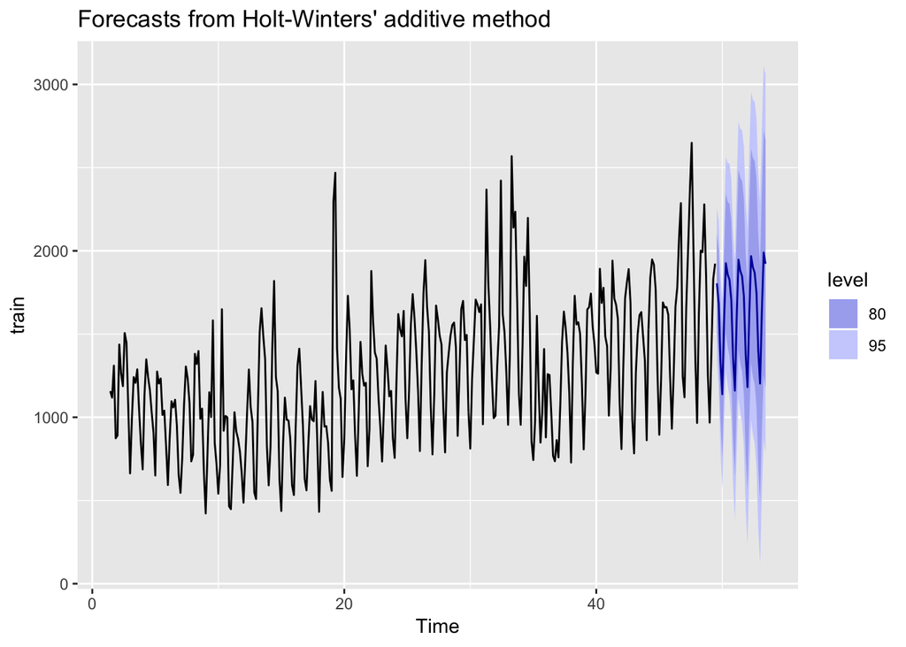

```r
# Plot the better forecasts
autoplot(fchw)
```

### State Space Models and Automatic Exponential Smoothing

The three possible trend components (None, Additive, Damped) and three possible seasonal components (None, Additive Multiplicative) gives us 9 possible Exponential Smoothing Methods.

> Each model consists of a measurement equation that describes the observed data, and some state equations that describe how the unobserved components or states (level, trend, seasonal) change over time. Hence, these are referred to as **state space models**.

> For each method there exist two models: one with **additive errors** and one with **multiplicative errors**. The point forecasts produced by the models are identical if they use the same smoothing parameter values. They will, however, generate different prediction intervals.

> To distinguish between a model with additive errors and one with multiplicative errors (and also to distinguish the models from the methods), we add a third letter to the classification. We label each state space model as ETS $(\cdot,\cdot,\cdot)$ for (Error, Trend, Seasonal).

##### Model Estimation and Model Selection

**Estimating the model parameters** can be done by minimising the sum of the squared errors. Alternatively, we can use **maximum likelihood**. The likelihood is the probability that the data is arising from the specified model, so a larger likelihood indicates a good model.  
For additive error model, maximum likelihood and minimising the SSE will give same results. But for multiplicative error models the results will be different.

**Model Selection** can be done using multiple ways e.g. Adjusted $R^2$, AIC, AICc and BIC. (TO DO : Review section 5.5 of the book). The ETS model uses Information Criteria for model selection.

*Note that*  
* *ETS(A,N,M), ETS(A,A,M) and ETS(A,$A_d$,M) can cause div by zero instabilities hence are not considered when selecting a model*  
* *Models with multiplicative errors are useful when the data are strictly positive, but are not numerically stable when the data contain zeros or negative values. Therefore, multiplicative error models will not be considered if the time series is not strictly positive. In that case, only the six fully additive models will be applied.*

The ets() function provides a completely automatic way of producing the forecasts. The ets() doesn’t produce forecasts on its own, so we have to pass it to the forecast() function.  
The ETS(A,A,N) is selected for the fitaus model and ETS(A,N,A) is selected for the fiths model. Note the Information Critieria values for fiths are very high and also it fails the residuals test. **(TO DO)**

```r
# Fit ETS model to austa in fitaus
fitaus <- ets(austa)
summary(fitaus)
```

```
## ETS(A,A,N)
##
## Call:
##  ets(y = austa)
##
##   Smoothing parameters:
##     alpha = 0.9999
##     beta  = 0.0085
##
##   Initial states:
##     l = 0.656
##     b = 0.1706
##
##   sigma:  0.1952
##
##      AIC     AICc      BIC
## 17.14959 19.14959 25.06719
##
## Training set error measures:
##                      ME      RMSE       MAE       MPE     MAPE      MASE
## Training set 0.00372838 0.1840662 0.1611085 -1.222083 5.990319 0.7907078
##                   ACF1
## Training set 0.2457733
```

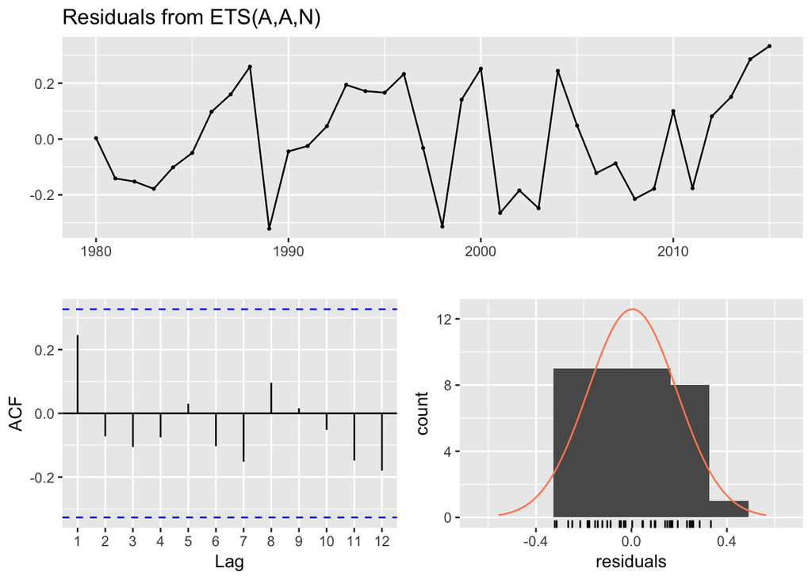

```
##
##  Ljung-Box test
##
## data:  Residuals from ETS(A,A,N)
## Q* = 4.8886, df = 3.2, p-value = 0.2022
##
## Model df: 4.   Total lags used: 7.2
```

```r
checkresiduals(fitaus)
```

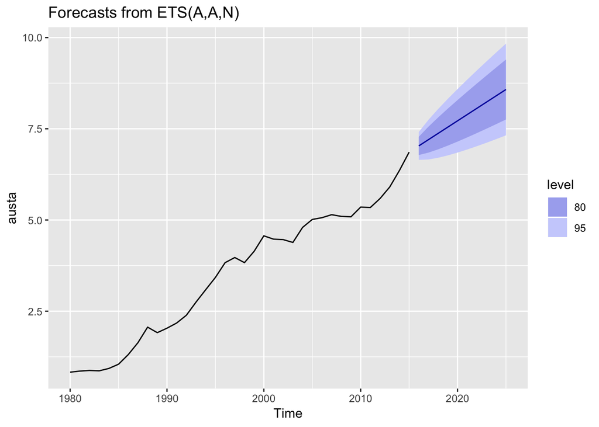

```r
# Plot forecasts
autoplot(forecast(fitaus))
```

```r
# Repeat for hyndsight data in fiths
fiths <- ets(hyndsight)
summary(fiths)
```

```
## ETS(A,N,A)
##
## Call:
##  ets(y = hyndsight)
##
##   Smoothing parameters:
##     alpha = 0.3628
##     gamma = 0.1009
##
##   Initial states:
##     l = 1154.1963
##     s = 258.076 -22.0077 -465.7618 -267.9975 127.4266 171.9474
##            198.317
##
##   sigma:  229.4593
##
##      AIC     AICc      BIC
## 6132.429 6133.051 6171.428
##
## Training set error measures:
##                    ME     RMSE     MAE       MPE  MAPE      MASE      ACF1
## Training set 4.441409 226.6127 162.477 -2.124126 13.47 0.7391041 0.2052565
```

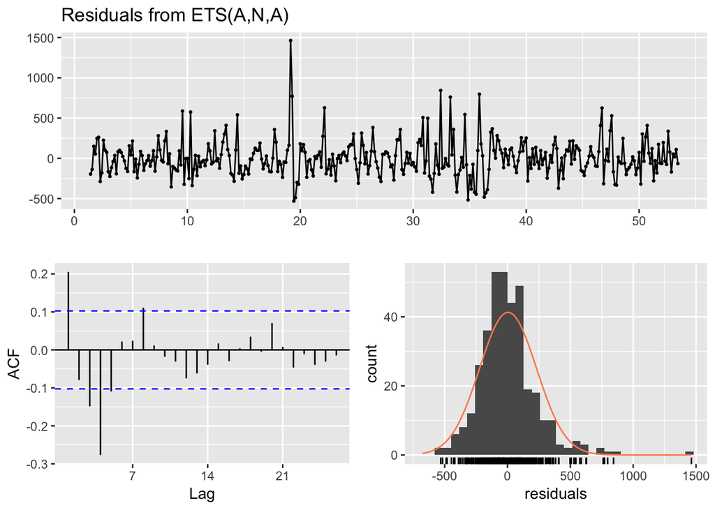

```
##
##  Ljung-Box test
##
## data:  Residuals from ETS(A,N,A)
## Q* = 68.616, df = 5, p-value = 1.988e-13
##
## Model df: 9.   Total lags used: 14
```

```r
checkresiduals(fiths)
```

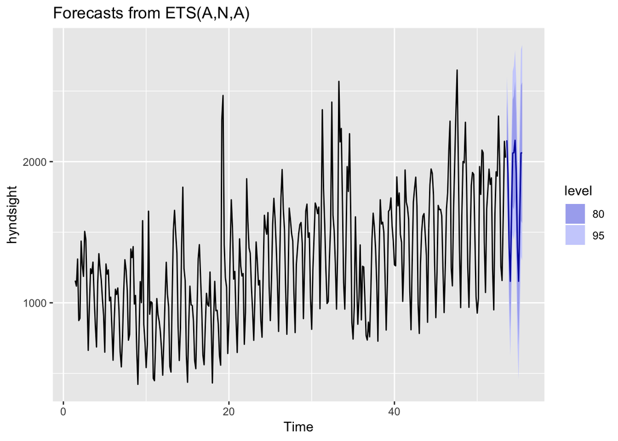

```r
autoplot(forecast(fiths))
```

```r
# Which model(s) fails test? (TRUE or FALSE)
fitausfail <- FALSE
fithsfail <- TRUE
```

Example with cement dataset (Not working as cement ds is not ts ???). eval has been set to FALSE

```r
frequency(cement)
# Function to return ETS forecasts
fets <- function(y, h) {
  forecast(ets(y), h = h)
}

# Apply tsCV() for both methods
e1 <- tsCV(cement, forecastfunction = fets, h = 4)
e2 <- tsCV(cement, forecastfunction = snaive, h = 4)

# Compute MSE of resulting errors (watch out for missing values)
mean(e1^2, na.rm=TRUE)
mean(e2^2, na.rm=TRUE)

# Copy the best forecast MSE
# Complex isn't always better !!!
bestmse <- mean(e2^2, na.rm=TRUE)
```

Example : Computing the ETS does not work well for all series.

Here, you will observe why it does not work well for the annual Canadian lynx population

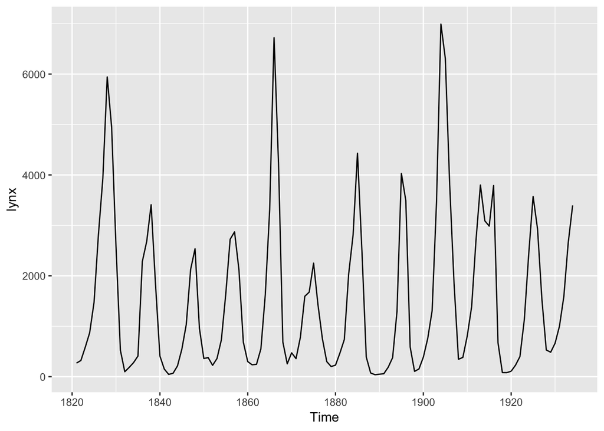

```r
# Plot the lynx series
autoplot(lynx)
```

```r
# Use ets() to model the lynx series
fit <- ets(lynx)

# Use summary() to look at model and parameters
summary(fit)
```

```
## ETS(M,N,N)
##
## Call:
##  ets(y = lynx)
##
##   Smoothing parameters:
##     alpha = 0.9999
##
##   Initial states:
##     l = 2372.8047
##
##   sigma:  0.9594
##
##      AIC     AICc      BIC
## 2058.138 2058.356 2066.346
##
## Training set error measures:
##                    ME     RMSE      MAE       MPE     MAPE     MASE
## Training set 8.975647 1198.452 842.0649 -52.12968 101.3686 1.013488
##                   ACF1
## Training set 0.3677583
```

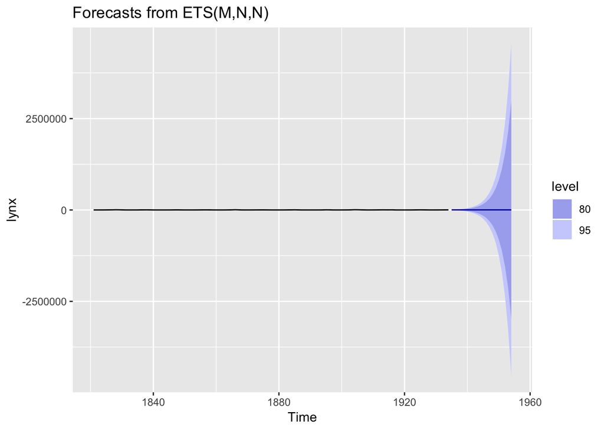

```r
# Plot 20-year forecasts of the lynx series
# It's important to realize that ETS doesn't work for all cases.
fit %>% forecast(h=20) %>% autoplot()
```

##### Match the plots

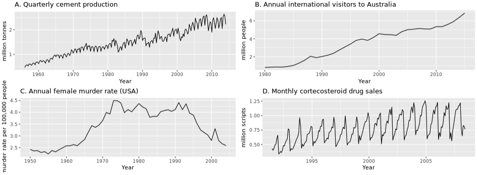

# Summary

- **Exponential Smoothing** is in between naive() that uses the last observation and meanf() that uses mean of all observations
- In **Simple Exponential Smoothing** $\alpha$ is the smoothing parameter that is estimated by the **ses() function** using least squares estimation
- **stats::fitted()** is a baseR function that extracts values from objects returned by modeling functions
- **autolayer()** uses ggplot2 to draw a particular layer eg **autolayer(fitted(ts_model))**
- **forecast::accuracy()** is used to compare models and gives summary of measures like ME, RMSE,MAE,MPE,MAPE, MASE,ACF1, Theil’s U
- **forecast::holt()** forecasts data with a trend, damped = TRUE is for the damped method
- Remember to use **summary() and checkresiduals()** to check the paramters and white noise respectively
- **hw(,seasonal = “additive/multiplicative”, m = frequency of seasonality)** is the extension of **holt()** to capture seasonality
- **ets()** (Error Trend Seasonal) automatically selects the best ESM model and we can produce forecasts using **forecast()**. Exceptions apply.
- The selected model can be seen using **summary()**. Parameter ($\alpha,\beta,\gamma$) estimation is done using maximum likelihood.
- **ets()** doesnt work for all time series